# Open Source can improve current scientific practice

### Ipython notebooks are a great tool to support this

**Sophie Balemans** and **Stijn Van Hoey**

*EGU 2015 - PICO session on Open Source Computing in Hydrology*

# The ideals of (hydrological) science

- Provide verifiable answers about water and solutions to water-related problems.
- The validation of these results by reproduction.
- An altruistic, collective enterprise for humanity's benefit

*F Perez*

# The ideals reality of (hydrological) science

- Provide verifiable answers about water and solutions to water-related problems.
  - **The pursuit of highly cited papers for your CV.**
- The validation of our results by reproduction.
  - **Validation by convincing journal referees who didn't see your code or data.**
- An altruistic, collective enterprise for humanity's benefit.
  - **A deadly race to outrun your colleagues in front of the bear of funding.**

*F Perez*

# Free and Open Source Software (FOSS) in this context

- Open, collaborative by definition.
  - Industrial competition can coexist...
- Continuous, public process.
  - Distributed credit.
  - Open peer review.
- Reproducible by necessity.
- Public bug tracking.
- The use of licenses is essential ([CC, BSD, GPL,...](http://choosealicense.com/))

*F Perez*

# FOSS $\neq$ free work

[figure not shown]

# All waiting for the developer...

[figure not shown]

## ...or all developers?

# Graveyard of good intentions

[figure not shown]

# Towards *continuous* and *collaborative*

What do we need:

- Training of students, Phds,...  
  *Creating a future generation of scientists with reproducibility as default*  
  Provide version control, script-based development, database management... in the curricula
- Continuous funding of open source development  
  *Payed to maintain and develop open source projects*
- Tools that facilitate a reproducible workflow  
  *[knitr](http://yihui.name/knitr/), [Ipython Notebook](http://ipython.org/notebook.html), [git](http://git-scm.com/), [RunMyCode](http://www.runmycode.org/), [VIStrails](http://www.vistrails.org), [Authorea](https://www.authorea.com),...*

## Ipython Notebook

# Reproducible science

- Reproducibility at publication time? is **TOO late!**

We need to embed the entire lifecycle of a scientific idea:

1. exploratory stuff
2. (collaborative) development
3. production (simulations on HPC, data visualisation,...)
4. publication (with reproducible results)
5. teach about it
6. Go back to 1.

**Ipython (Jupyter!) Notebook** can support on the different levels

**Ipython (Jupyter!) Notebook...** (*this is a notebook!*)

### Minimize effort between analysis and sharing

[figure not shown]

- Interactive shell for data-analysis and exploration
- Interaction between languages (R, Julia,...)
- Parallel computing
- ipynb to latex, pdf, html, html,slides, publications, books,...
- Loading of images, websites, widgets,...
- ...

Check it out on https://github.com/ipython/ipython/wiki/A-gallery-of-interesting-IPython-Notebooks

# Scripts, so it can be *version controlled!*

[figure not shown]

# Recap *5. teach about it*

- The same file can be used to do analysis, create course notes and retrieve slides using nbconvert
- Students can interactively work on their notebook
- Different useful features: eg.

## interactive widgets

## Conceptual rainfall-runoff model

[figure not shown]

Measured vs modelled discharge:

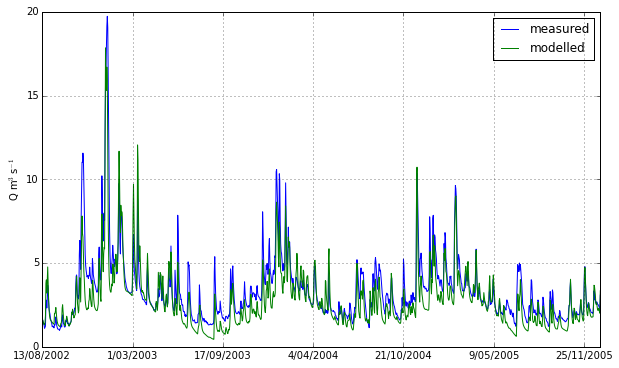

```python
fig, ax = plt.subplots(figsize=(10, 6))
p1 = measured.plot(ax=ax, label='measured')
p2 = modeloutput1.plot(ax=ax, label='modelled')
t = ax.set_ylabel(r'Q m$^3$s$^{-1}$')
plt.legend(['measured', 'modelled'])
```

# Exploring the parameter space

- Simulating 20000 Monte-Carlo runs
- Sampling from uniform distribution
- Parallel calculation within IPython notebook

### Visualisation in 2D scatter plot

```python
from scatter_hist_season import create_scatterhist
```

```
Current threshold = 674.854206156
Number of behavioural parametersets = 7910 out of 20000
```

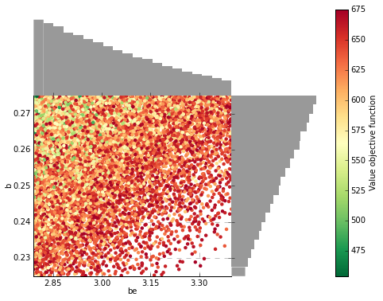

```python
scatter = create_scatterhist(pars, 2, 1, objective_functions, names,
                                            objective_function='SSE',
                                            threshold=0.4,
                                            season = 'Winter')
```

```
Current threshold = 105.663890284
Number of behavioural parametersets = 9592 out of 20000
```

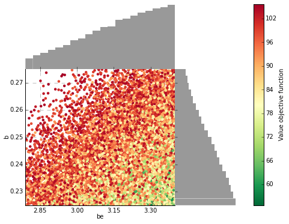

```python
scatter = create_scatterhist(pars, 2, 1, objective_functions, names,
                                            objective_function='SSE',
                                            threshold=0.4,
                                            season = 'Spring')
```

### What about the model?

- Parameter boundaries correct?
- Optimal paramersets change periodically... Correct model structure?
- **NOT** an optimization tool!

## More interactive?

### command:

```
interact(...)
```

```python
#Loading interact functionality
from IPython.html.widgets import interact, fixed
```

```
interact(create_scatterhist,*args, **kwargs)
```

- input list => dropdown

  ```
    objective_function = ['SSE', 'RMSE', 'RRMSE']
    season = ['Winter','Summer',
                    'Spring', 'Autumn','All season']
  ```

- input array => slider

  ```
    threshold=(0,1,0.005)
  ```

[figure not shown]

# Ipython notebook...

[figure not shown]

- [Github Stijn Van Hoey](https://github.com/stijnvanhoey) stvhoey.vanhoey@ugent.be, @SVanHoey
- [Github Sophie](https://github.com/sbalemans) sophie.balemans@ugent.be
- [Github university](https://github.ugent.be/biomath)